# UJI ASUMSI KLASIK

## **What is one-way ANOVA test?**

The one-way analysis of variance (ANOVA), also known as one-factor ANOVA, is an extension of independent two-samples t-test for comparing means in a situation where there are more than two groups. In one-way ANOVA, the data is organized into several groups base on one single grouping variable (also called factor variable). This tutorial describes the basic principle of the one-way ANOVA test and provides practical anova test examples in R software.

## **Assumptions of ANOVA test**

Here we describe the requirement for **ANOVA test**. ANOVA test can be applied only when: - The observations are obtained independently and randomly from the population defined by the factor levels** - The data of each factor level are normally distributed. - These normal populations have a common variance. (Levene’s test can be used to check this.)

**Packages Required** **install.packages(agricolae)** **install.packages(ggpubr)**

**Additional tools** **if(!require(devtools)) install.packages(“devtools”)** **devtools::install_github(“kassambara/ggpubr”)**

## **Import your data into R**

```r
## Loading the iris data
data("iris")
head(iris)
```

|  | Sepal.Length | Sepal.Width | Petal.Length | Petal.Width | Species |
| --- | --- | --- | --- | --- | --- |
| 1 | 5.1 | 3.5 | 1.4 | 0.2 | setosa |
| 2 | 4.9 | 3.0 | 1.4 | 0.2 | setosa |
| 3 | 4.7 | 3.2 | 1.3 | 0.2 | setosa |
| 4 | 4.6 | 3.1 | 1.5 | 0.2 | setosa |
| 5 | 5.0 | 3.6 | 1.4 | 0.2 | setosa |
| 6 | 5.4 | 3.9 | 1.7 | 0.4 | setosa |

|  | Sepal.Length <dbl> | Sepal.Width <dbl> | Petal.Length <dbl> | Petal.Width <dbl> | Species <fct> |
| --- | --- | --- | --- | --- | --- |
| 1 | 5.1 | 3.5 | 1.4 | 0.2 | setosa |
| 2 | 4.9 | 3.0 | 1.4 | 0.2 | setosa |
| 3 | 4.7 | 3.2 | 1.3 | 0.2 | setosa |
| 4 | 4.6 | 3.1 | 1.5 | 0.2 | setosa |
| 5 | 5.0 | 3.6 | 1.4 | 0.2 | setosa |
| 6 | 5.4 | 3.9 | 1.7 | 0.4 | setosa |

6 rows

```r
str(iris)
```

```
## 'data.frame':    150 obs. of  5 variables:
##  $ Sepal.Length: num  5.1 4.9 4.7 4.6 5 5.4 4.6 5 4.4 4.9 ...
##  $ Sepal.Width : num  3.5 3 3.2 3.1 3.6 3.9 3.4 3.4 2.9 3.1 ...
##  $ Petal.Length: num  1.4 1.4 1.3 1.5 1.4 1.7 1.4 1.5 1.4 1.5 ...
##  $ Petal.Width : num  0.2 0.2 0.2 0.2 0.2 0.4 0.3 0.2 0.2 0.1 ...
##  $ Species     : Factor w/ 3 levels "setosa","versicolor",..: 1 1 1 1 1 1 1 1 1 1 ...
```

```r
levels(iris$Species)
```

```
## [1] "setosa"     "versicolor" "virginica"
```

## **Compute summary statistics by groups - count, mean, sd:**

```r
library(dplyr)
group_by(iris, Species) %>%
  summarise(
    count = n(),
    mean = mean(Sepal.Length, na.rm = TRUE),
    sd = sd(Sepal.Length, na.rm = TRUE)
  )
```

| Species | count | mean | sd |
| --- | --- | --- | --- |
| setosa | 50 | 5.006 | 0.3524897 |
| versicolor | 50 | 5.936 | 0.5161711 |
| virginica | 50 | 6.588 | 0.6358796 |

| Species <fct> | count <int> | mean <dbl> | sd <dbl> |  |
| --- | --- | --- | --- | --- |
| setosa | 50 | 5.006 | 0.3524897 |  |
| versicolor | 50 | 5.936 | 0.5161711 |  |
| virginica | 50 | 6.588 | 0.6358796 |  |

3 rows

## **Visualize your data**

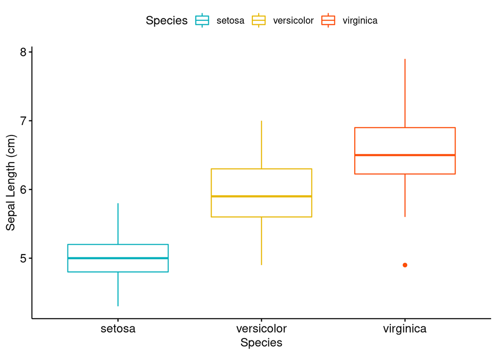

```r
# Box plots
# ++++++++++++++++++++
# Plot Sepal Lenght by Species and color by Species
library("ggpubr")
ggboxplot(iris, x = "Species", y = "Sepal.Length",
          color = "Species", palette = c("#00AFBB", "#E7B800", "#FC4E07"),
          order = c("setosa", "versicolor", "virginica"),
          ylab = "Sepal Length (cm)", xlab = "Species")
```

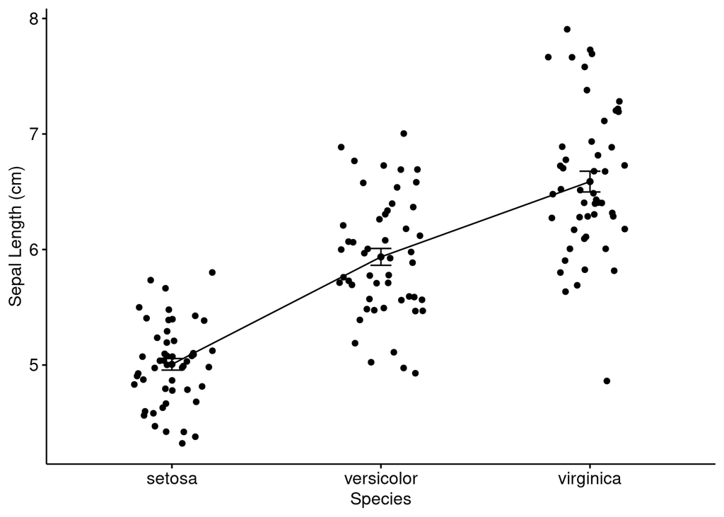

```r
# Mean plots
# ++++++++++++++++++++
# Plot Sepal Lenght by Species
# Add error bars: mean_se
# (other values include: mean_sd, mean_ci, median_iqr, ....)
library("ggpubr")
ggline(iris, x = "Species", y = "Sepal.Length",
          add = c("mean_se", "jitter"),
          order = c("setosa", "versicolor", "virginica"),
          ylab = "Sepal Length (cm)", xlab = "Species")
```

## *Compute one-way ANOVA test*

```r
library(agricolae)
AOV <- aov(Sepal.Length ~ Species, iris)
summary(AOV)
```

```
##              Df Sum Sq Mean Sq F value Pr(>F)
## Species       2  63.21  31.606   119.3 <2e-16 ***
## Residuals   147  38.96   0.265
## ---
## Signif. codes:  0 '***' 0.001 '**' 0.01 '*' 0.05 '.' 0.1 ' ' 1
```

## **Multiple pairwise-comparison between the means of groups**

In one-way ANOVA test, a significant p-value indicates that some of the group means are different, but we don’t know which pairs of groups are different.

It’s possible to perform multiple pairwise-comparison, to determine if the mean difference between specific pairs of group are statistically significant.

## **Tukey multiple pairwise-comparisons**

As the ANOVA test is significant, we can compute Tukey HSD (Tukey Honest Significant Differences, R function: TukeyHSD()) for performing multiple pairwise-comparison between the means of groups.

The function **HSD.test()** takes the fitted ANOVA as an argument.

```r
TUKEY<-HSD.test(AOV, "Species", console= TRUE)
```

```
##
## Study: AOV ~ "Species"
##
## HSD Test for Sepal.Length
##
## Mean Square Error:  0.2650082
##
## Species,  means
##
##            Sepal.Length       std  r Min Max
## setosa            5.006 0.3524897 50 4.3 5.8
## versicolor        5.936 0.5161711 50 4.9 7.0
## virginica         6.588 0.6358796 50 4.9 7.9
##
## Alpha: 0.05 ; DF Error: 147
## Critical Value of Studentized Range: 3.348424
##
## Minimun Significant Difference: 0.2437727
##
## Treatments with the same letter are not significantly different.
##
##            Sepal.Length groups
## virginica         6.588      a
## versicolor        5.936      b
## setosa            5.006      c
```

## **Plot Tukey multiple pairwise-comparisons**

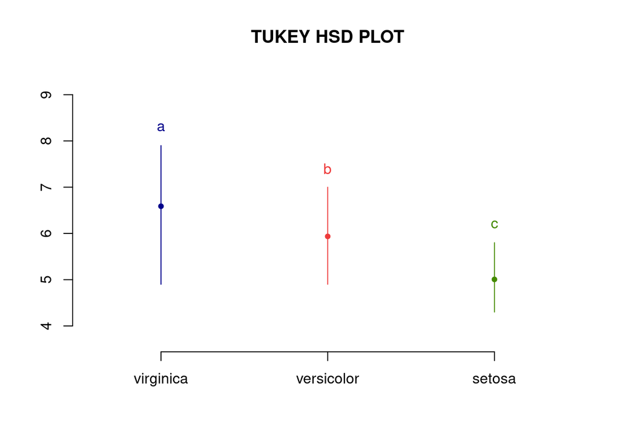

```r
plot(TUKEY, main = "TUKEY HSD PLOT")
```

## **Check ANOVA assumptions: test validity?**

The ANOVA test assumes that, the data are normally distributed and the variance across groups are homogeneous. We can check that with some diagnostic plots.

### **1. Homogeneity of variances**

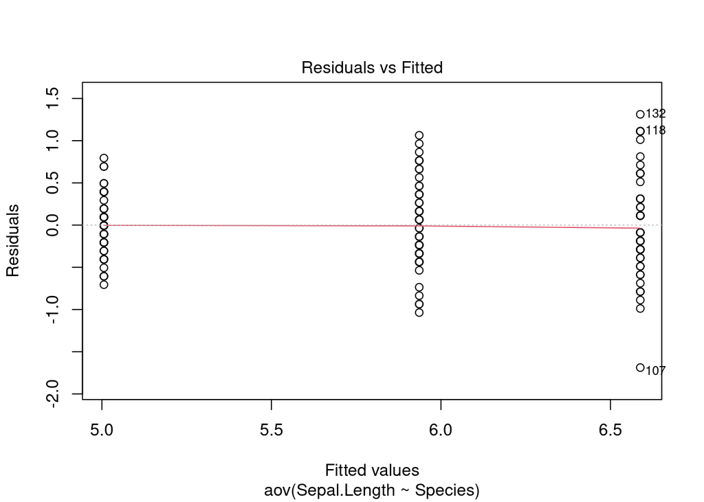

```r
plot(AOV, 1)
```

**It’s also possible to use Bartlett’s test or Levene’s test to check the homogeneity of variances.**

We recommend Levene’s test, which is less sensitive to departures from normal distribution. The function **leveneTest()** [in **car** package] will be used:

```r
library(car)
leveneTest(Sepal.Length ~ Species, iris)
```

|  | Df | F value | Pr(>F) |
| --- | --- | --- | --- |
| group | 2 | 6.35272 | 0.002258528 |
|  | 147 | NA | NA |

|  | Df <int> | F value <dbl> | Pr(>F) <dbl> |  |
| --- | --- | --- | --- | --- |
| group | 2 | 6.35272 | 0.002258528 |  |
|  | 147 | NA | NA |  |

2 rows

From the output above we can see that the p-value is less than the significance level of 0.05. This means that there is evidence to suggest that the variance across groups is statistically significantly different. Therefore, we can assume the non homogeneity of variances in the different treatment groups.

### **2.Relaxing the homogeneity of variance assumption**

An alternative procedure (i.e.: **Welch one-way test**), that does not require that assumption have been implemented in the function **oneway.test()**.

- **ANOVA test with no assumption of equal variances**

```r
oneway.test(Sepal.Length ~ Species, iris)
```

```
##
##  One-way analysis of means (not assuming equal variances)
##
## data:  Sepal.Length and Species
## F = 138.91, num df = 2.000, denom df = 92.211, p-value < 2.2e-16
```

- **Pairwise t-tests with no assumption of equal variances**

```r
pairwise.t.test(iris$Sepal.Length, iris$Species,
                 p.adjust.method = "BH", pool.sd = FALSE)
```

```
##
##  Pairwise comparisons using t tests with non-pooled SD
##
## data:  iris$Sepal.Length and iris$Species
##
##            setosa  versicolor
## versicolor < 2e-16 -
## virginica  < 2e-16 1.9e-07
##
## P value adjustment method: BH
```

### **3.Check the normality assumption**

Normality plot of residuals. In the plot below, the quantiles of the residuals are plotted against the quantiles of the normal distribution. A 45-degree reference line is also plotted.

The normal probability plot of residuals is used to check the assumption that the residuals are normally distributed. It should approximately follow a straight line.

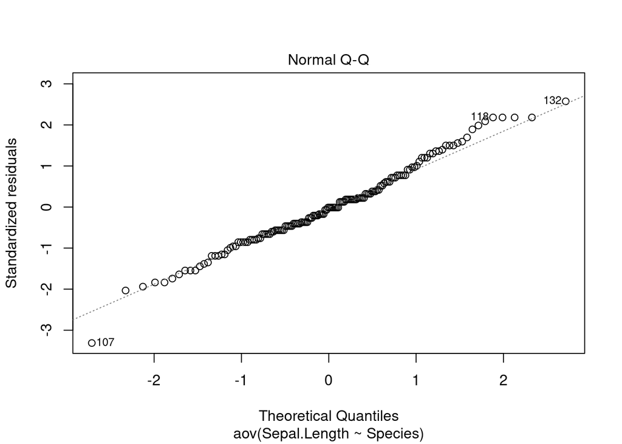

```r
plot(AOV, 2)
```

As all the points fall approximately along this reference line, we can assume normality.

```r
# Extract the residuals
aov_residuals <- residuals(object = AOV )
# Run Shapiro-Wilk test
shapiro.test(x = aov_residuals )
```

```
##
##  Shapiro-Wilk normality test
##
## data:  aov_residuals
## W = 0.9879, p-value = 0.2189
```

## **Non-parametric alternative to one-way ANOVA test**

Note that, a non-parametric alternative to one-way ANOVA is Kruskal-Wallis rank sum test, which can be used when ANNOVA assumptions are not met.

```r
kruskal.test(Sepal.Length ~ Species, iris)
```

```
##
##  Kruskal-Wallis rank sum test
##
## data:  Sepal.Length by Species
## Kruskal-Wallis chi-squared = 96.937, df = 2, p-value < 2.2e-16
```